# Packages tigris and ACS and plotting school district data.

R provides easy to use packages that wrap the census TIGER shapefile database and the census American Community Survey database. Because of this, it is easy to plot reasonable maps in R of descriptive statistics at the district level for a given state.

Furthermore, with a little bit of object hacking, you can create a geojson file useable in Tableau for your own purposes.

```r
library(rgdal) # Used for outputting geojson files, and a dependency for tigris
library(tigris) # Intertface for the TIGER database
library(acs) # Interface for the ACS API
library(rgeos) # For cropping
library(raster) # For cropping
library(rgdal) # For outputting geoJSON -- Not actually executed in RMD
library(dplyr) # For ACS munging
```

You will need to request an API key from the census bureau for ACS API integration at:

http://api.census.gov/data/key_signup.html

# Downloading School District Shapefiles

To download school district shapefiles we use the

```r
school_districts()
```

function from tigris.

Two arguments are required: State, which takes 2-letter state abbreviations, and type

Three kinds of school district shapefiles exist in TIGER:

- Unified districts (type = “unified”)
- Elementary districts (type = “elementary”)
- Secondary districts (type = “secondary”)

To get a basic unified district shapefile for Mass.:

```r
MA_unified <- school_districts(state = "MA",
                               type = "unified")
```

# Hacking school district shapefiles together.

If you plot the unified districts, you won’t get what you expect, exactly:

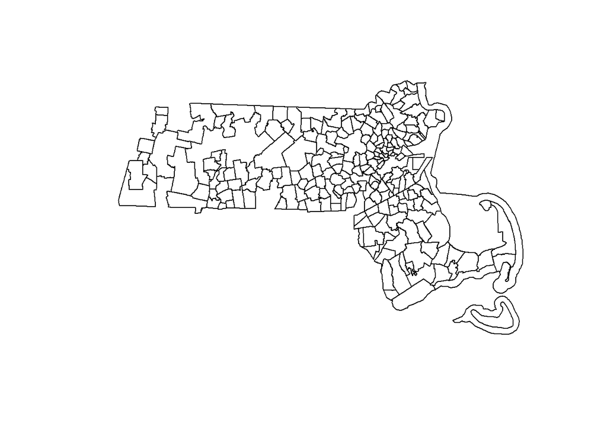

```r
plot(MA_unified)
```

We will need to bring in the secondary and elementary districts to get the expected plot.

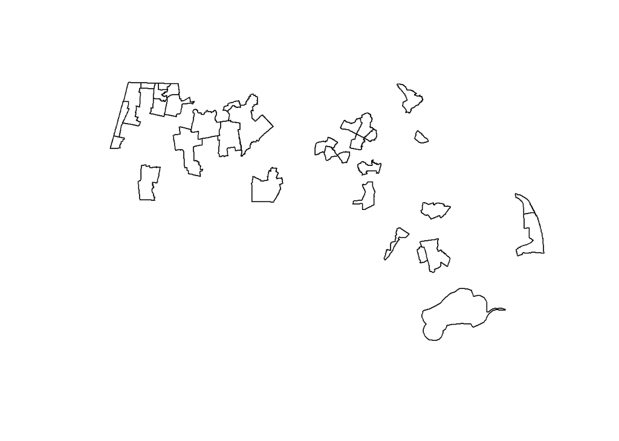

```r
MA_secondary <- school_districts(state = "MA",
                                 type = "secondary")

MA_elementary <- school_districts(state = "MA",
                                  type = "elementary")
plot(MA_secondary)
```

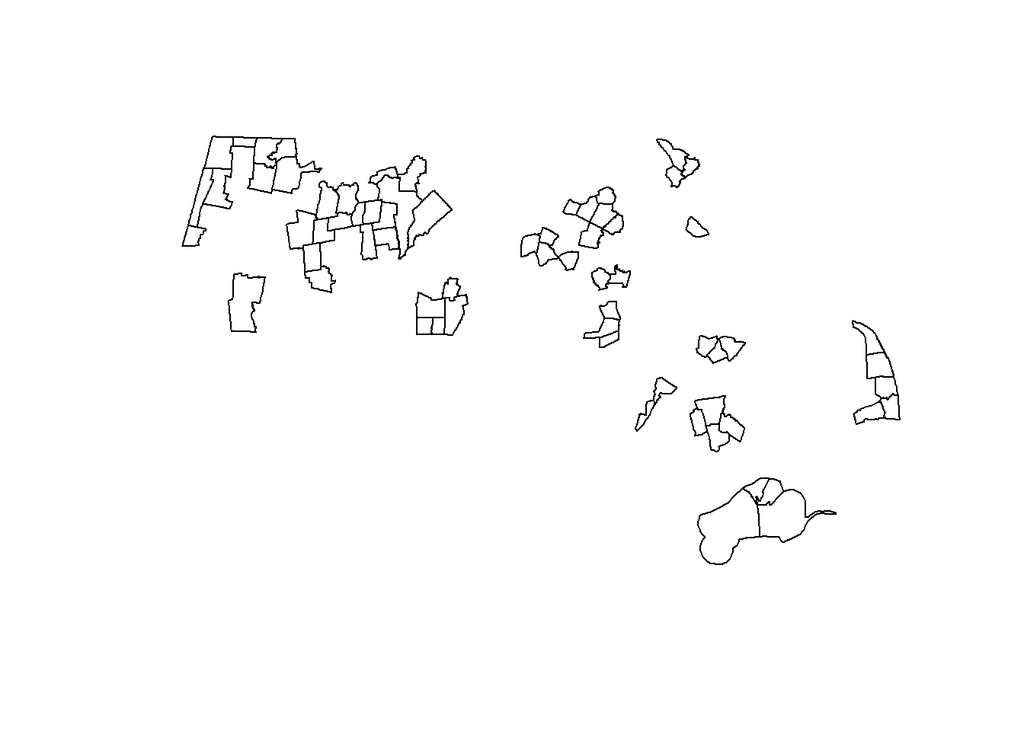

```r
plot(MA_elementary)
```

Sadly, for the time being, the built-in tigris function

```r
rbind_tigris()
```

to handle shapefile merging doesn’t work with multiple tigris shapefile types, which different districts technically are (there is a pull request in to change this.)

```r
test <- rbind_tigris(MA_elementary, MA_secondary)
```

```
## Error: Objects must all be Spatial*DataFrame objects and all the same type of tigris object.
```

For the time being, we can hack around this by:

1. Changing the tigris attribute for each shape file object.
2. Renaming the “SDLEA”" columns for tigris_dataframe@data.

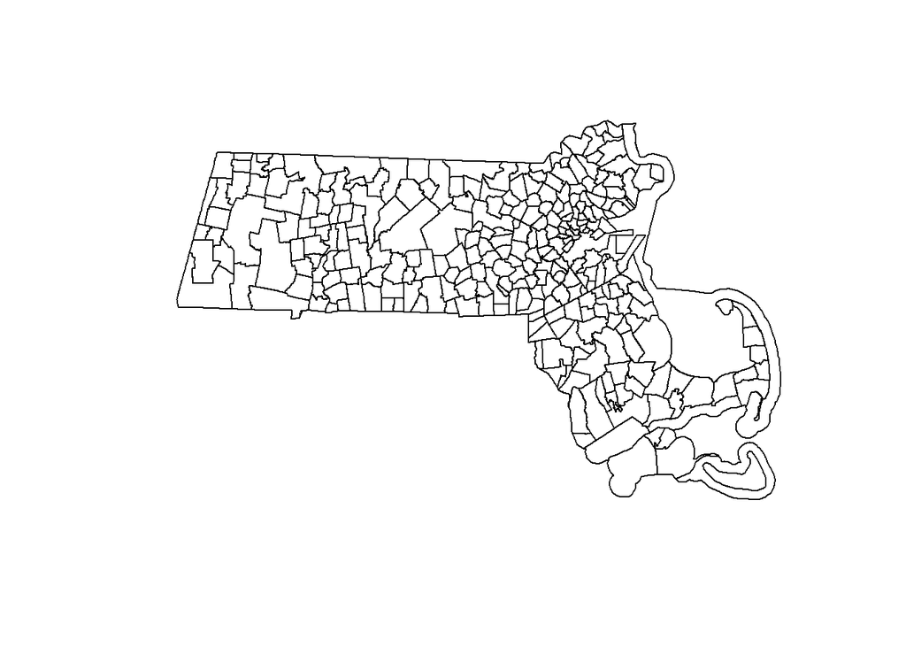

```r
attr(MA_unified, "tigris") <- "sdall"
attr(MA_secondary, "tigris") <- "sdall"
attr(MA_elementary, "tigris") <- "sdall"

names(MA_unified@data)[2] <- "SDLEA"
names(MA_secondary@data)[2] <- "SDLEA"
names(MA_elementary@data)[2] <- "SDLEA"

MA_all_sd <- rbind_tigris(MA_unified,
                          MA_secondary,
                          MA_elementary)

plot(MA_all_sd)
```

Still not quite there – There’s those polygons over water. Peeking inside the @data gives a clue and we have a way to remove those polygons.

```r
names(MA_all_sd@data)
```

```
##  [1] "STATEFP"  "SDLEA"    "GEOID"    "NAME"     "LSAD"     "LOGRADE"
##  [7] "HIGRADE"  "MTFCC"    "SDTYP"    "FUNCSTAT" "ALAND"    "AWATER"
## [13] "INTPTLAT" "INTPTLON"
```

```r
# Any with no LAND area?
MA_all_sd@data[which(MA_all_sd@data$ALAND == "0"), ]
```

```
##                                     STATEFP SDLEA   GEOID
## 851da7b2249111e788252548a19d22ef208      25 99997 2599997
##                                                            NAME LSAD
## 851da7b2249111e788252548a19d22ef208 School District Not Defined   00
##                                     LOGRADE HIGRADE MTFCC SDTYP FUNCSTAT
## 851da7b2249111e788252548a19d22ef208      PK      12 G5420  <NA>        F
##                                     ALAND     AWATER    INTPTLAT
## 851da7b2249111e788252548a19d22ef208     0 4005479391 +41.8843837
##                                         INTPTLON
## 851da7b2249111e788252548a19d22ef208 -070.3594513
```

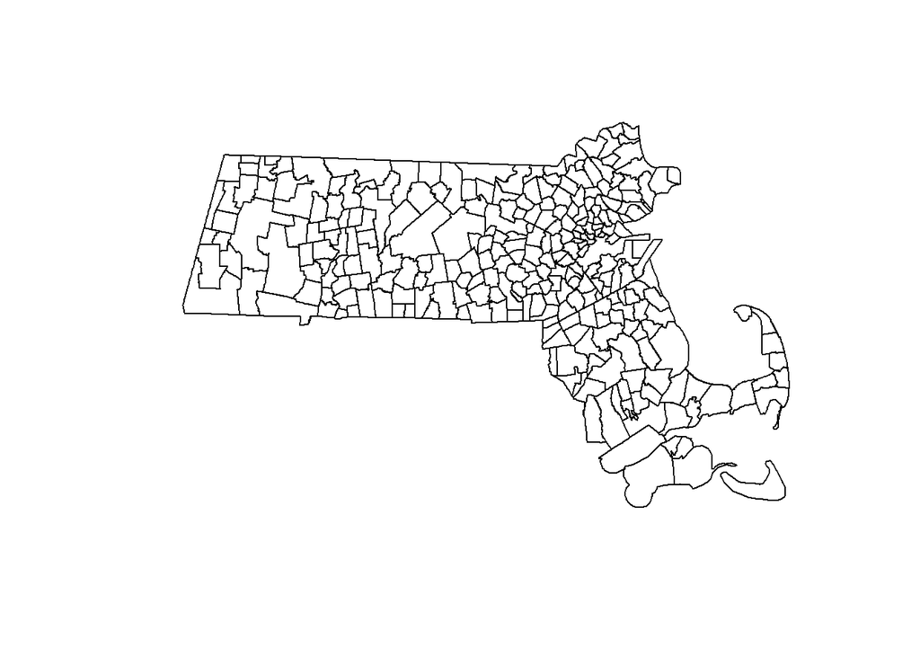

```r
# Remove them.
MA_all_sd <- MA_all_sd[which(MA_all_sd@data$ALAND != "0"), ]

plot(MA_all_sd)
```

Still not quite there.

A county shapefile from tigris using the catrographic boundaries (cb=TRUE) to crop down to the land will result in what we want. Cartographic boundaries isn’t callable on school districts, but for areas that it is, it gives outlines without land.

```r
outline <- counties(state = "MA",
                    cb = TRUE,
                    resolution = "500k",
                    detailed = TRUE)

outline <- gUnaryUnion(outline)

dim(MA_all_sd)
```

```
## [1] 308  14
```

```r
MA_all_sd_land <- rgeos::intersect(MA_all_sd, outline)

dim(MA_all_sd_land)
```

```
## [1] 307  14
```

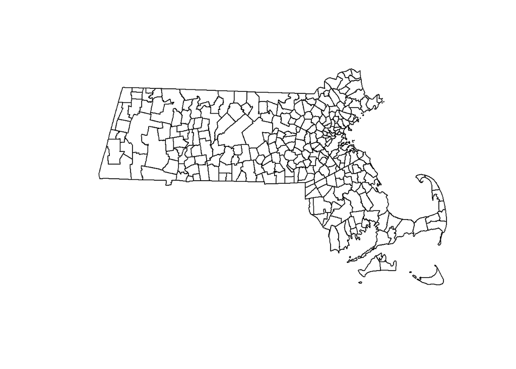

```r
plot(MA_all_sd_land)
```

@Data is maintained:

```r
head(MA_all_sd_land, n = 2)
```

```
##   STATEFP SDLEA   GEOID                                    NAME LSAD
## 1      25 00001 2500001                 Quabbin School District   00
## 2      25 00002 2500002 Spencer-East Brookfield School District   00
##   LOGRADE HIGRADE MTFCC SDTYP FUNCSTAT     ALAND   AWATER    INTPTLAT
## 1      PK      12 G5420  <NA>        E 428888135 10412084 +42.3975002
## 2      PK      12 G5420  <NA>        E 110554617  4468585 +42.2311461
##       INTPTLON
## 1 -072.1036444
## 2 -072.0057166
```

We’ll pull in ACS data separately, and do our join in Tableau.

You will need to have gotten your ACS API key already, and added it via: api.key.install(key = “your key here”)

There’s a world of ACS tables. Peruse to your taste. For this, we are going to use Median Household Income – B19013

We need to make 3 geographic areas, for each SD type again, do some munging, and then export.

Do a straight up left join in Tableau with the geojson as the primary data set on SDLEA.

NOTE: If one of the SDLEAs comes in as numeric, convert to String in Tableau for the join to work.

```r
# Set geographic areas for acs.fetch()
MA_geo_uni <- geo.make(state = "MA", school.district.unified = "*", combine = FALSE)
MA_geo_sec <- geo.make(state = "MA", school.district.secondary = "*", combine = FALSE)
MA_geo_elem <- geo.make(state = "MA", school.district.elementary = "*", combine = FALSE)

#Pull the data
median_hhi_uni <- acs.fetch(endyear = 2015, span = 5, geography = MA_geo_uni, table.number = "B19013", col.names = "pretty")
median_hhi_sec <- acs.fetch(endyear = 2015, span = 5, geography = MA_geo_sec, table.number = "B19013", col.names = "pretty")
median_hhi_elem <- acs.fetch(endyear = 2015, span = 5, geography = MA_geo_elem, table.number = "B19013", col.names = "pretty")

#Get the applicable stuff out of the objects
mhhi_uni_dat <- bind_cols(data.frame(median_hhi_uni@geography), data.frame(median_hhi_uni@estimate))
mhhi_sec_dat <- bind_cols(data.frame(median_hhi_sec@geography), data.frame(median_hhi_sec@estimate))
mhhi_elem_dat <- bind_cols(data.frame(median_hhi_elem@geography), data.frame(median_hhi_elem@estimate))

#Rename for row_binding
names(mhhi_uni_dat)[3] <- "SDLEA"
names(mhhi_sec_dat)[3] <- "SDLEA"
names(mhhi_elem_dat)[3] <- "SDLEA"

#Bind
mhhi_sdall <- bind_rows(mhhi_elem_dat, mhhi_sec_dat, mhhi_uni_dat)

#Merge into shapefile
write.csv(mhhi_sdall, "mhhi_sdall.csv", row.names = FALSE)

#Write the .geojson
writeOGR(MA_all_sd_land, "MA_all_sd_land.geojson", layer="MA_all_sd_land", driver="GeoJSON")
```

Check out [the geoJSON dumped to Tableau Public](https://public.tableau.com/views/Pretty-fiedMASDs_/Sheet1?:embed=y&:display_count=yes) for the result!

Sources

[tigris by Dr. Kyle Walker via CRAN](https://cran.r-project.org)

[Stack Overflow user cengel for the cropping](https://gis.stackexchange.com/a/173263)

[For ggplot2 mapping and easier ACS plotting](http://zevross.com/blog/2015/10/14/manipulating-and-mapping-us-census-data-in-r-using-the-acs-tigris-and-leaflet-packages-3/)